# An Analysis of the Effect of Gender, Criminal History, and Education on Income using the National Longitudinal Survey of Youth, 1997 (NLSY97)

Tobi Jegede, Kyle Soto, and Callie Lambert

December 14, 2020

### Starter Information

#### Variables present in the base data set

### Data Processing and Summarization

#### Subsetting the Data

We chose three main buckets of factors on which to analyze how income in 2017 was affected by gender in the National Longitudinal Study of Youth in 1997:

1. Demographic information (age, race, physical or emotional condition limiting work, citizenship status, urban/rural residence, number of children in the household under the age of 6, and marital status)
2. Educational background (the highest educational attainment of mother and father, and the respondent’s highest degree received)
3. Criminal history (total number of incarcerations and the length of the longest period of incarceration).

#### Variables Considered But Not Included

The NLSY dataset offers 95 variables for analysis. Prior to selecting a subset of variables, we considered and discussed many others.

Notably, the dataset includes separate variables for educational achievements of biological parents. For this analysis, residential parents were selected to assess the impact of the respondents’ home environment on future income.

The dataset includes a variable that measures if the respondent is unhappy, sad, or depressed. Instead of using this variable, we chose the variable that measures if the respondent has a physical or mental condition that limits school or work. `condition.limiting.work` is an objective measure of conditions that may impact future earnings. The unhappy, sad, or depressed variable was coded as “not true”, “sometimes true” or “often true”, which was a more subjective variable than the `condition.limiting.work` variable, for which respondents either gave a “yes” or “no” response to this variable.

We chose our criminal history variables, `num.times.incarc` and `longest.length.incarc.months` on the basis that we wanted objective datapoints of a respondent’s incarceration history. There is a variable in the larger dataset that examined the respondent’s perception of the likelihood that they would be incarcerated by age 20. The question that generated this variable was asked when the participants were teenagers in 1997. Due to the high level of subjectivity in answering the “percent chance of incarceration” variable, we thought that `num.times.incarc` and `longest.length.incarc.months` would be better suited for our analysis.

When looking for household conditions that could variably impact income between men and women, we thought that the number of children in the household could have an impact on income. We initially considered using a variable that measured the amount of biological children for each respondent. We ultimately decided to use the `num.children.under.6` variable, however, because we were interested in understanding how enhanced childcare needs for younger children had a different impact on income based on sex. Additionally, the number of biological children that a respondent had didn’t necessarily mean that the child actually lived in the household. Therefore, we chose `num.children.under.6` because it provides a better snapshot of household conditions.

Finally, we also considered looking at the financial assets and debt that participants held. We ultimately decided not to include these variables as they would likely be highly correlated with the income variable. In order to reduce the introduction of collinearity into our model, we chose not to include these variables. Additionally, some of the financial variables might be considered dependent outcomes as well - this was another reason for their exclusion.

### Recoding the Subset of Variables

#### Recoding Methodology

For the categorical variables, the negative values were recoded based on how they appeared in the codebook, i.e. -4 = “Invalid Skip”, etc.

For the numerical variables, the negative values that corresponded to “Non-Interview”, or “Invalid Skip” were recoded as “NA” because there was no useful interpretation for these values in the larger context of the variable. For some of the negative values corresponding to a “Valid Skip”, these were recoded as “0”. Further discussion of the recoding methodology is explained for each of the 14 variables selected for analysis.

Many variables were recoded as factor variables. This was done in cases where the order of the categories mattered (e.g., `residential.dad.highest.grade.bucket`) or to select a specific baseline group.

#### Processing Income Topcoding

In order to do further analysis later in our project, we also created a subset of the dataset where the topcoding on the income variable was removed. The income for the minimum salary in the top 2% (149,000), which was also used as truncation for topcoding, was left in this subset as this represented a respondent’s exact income rather than the average used for topcoded incomes.

We also created a subset of the data that contains only the respondents with topcoded income. This group contains the “high earners” and there is some independent exploration of this group to understand how they deviate from the other respondents.

### Tabular & Graphical Summaries

#### Main Independent Variable: Sex

| Sex | Overall Count | Percentage of Total Population |
| --- | --- | --- |
| Female | 4,385 | 48.81 |
| Male | 4,599 | 51.19 |

From the summary data, we can see that there is a roughly equal percentage of women and men in the subset of dataset that will be used as the basis for our analysis. The dataset is 48.8% female and 51.2% male.

#### Main Dependent (Outcome) Variable: Income

When analyzing the income variable, we started by eliminating the negative values. This rationale was based on the fact that the value of “-5” corresponded to a “Non-Interview” which meant that 2,250 participants were not even asked this particular question, therefore it would not make sense to include these respondents in this subset of the dataset.

Additionally, the value of “-1” corresponded to a “Refusal” to answer this question, which again would not have a useful interpretation in the context of the remaining values available for this question.

A value of “-2” corresponded to “Don’t Know”. Respondents who provided this answer were then prompted to answer another question about their estimated income for 2017 but not all participants who were sent to the “estimated income from wages and salary in the past year” question provided a response, which again eliminated the ability to include these respondents in our income variable.The information captured from the question that generated the “income” variable and the question that generated the “estimated income” variable are also not measured with the same methodolgy. The `income` variable provides exact numbers of the income that the respondent made, while the question directly following the “total income from wages and salary in the past year” only provides responses in pre-defined intervals, with no access to the underlying values.

The value of “-4” for the income variable corresponded to a “Valid Skip”, although it is not clear what the criteria was that allowed a participant to skip this question. After exploring the negative values for `income` a bit further, we decided that the best course of action would be to recode the negative values for the income varible as “NA”.

After completing our recoding, we then did some graphical analysis of the distribution of income in the dataset.

**Graphical Summary of Income**

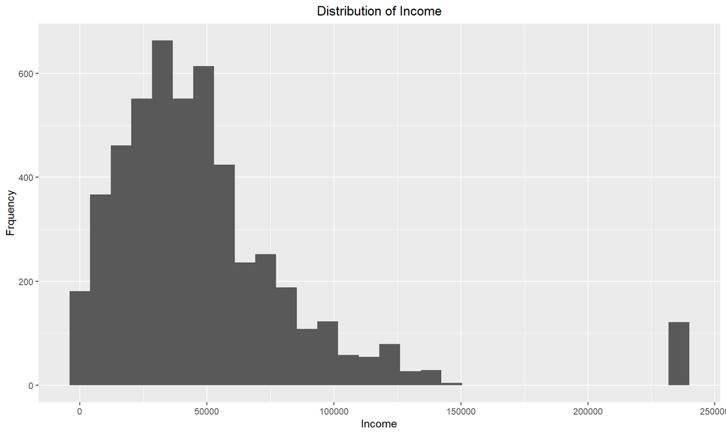

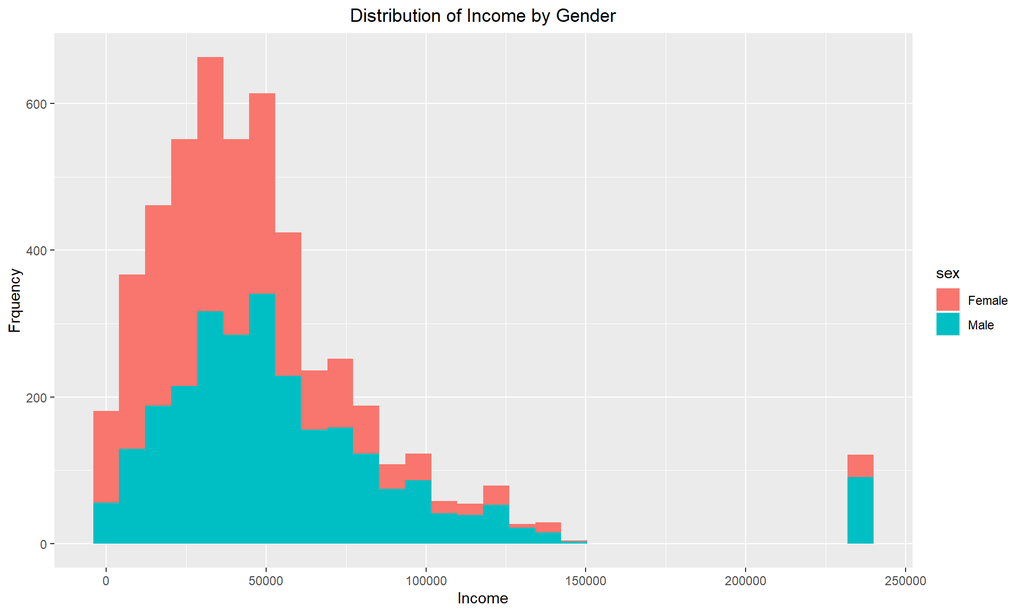

Breakdown of Income by Sex

| Sex | Count | $0 (in %) | $1-$50,000(in %) | $50,000-$100,000(in %) | $100,000-$149,000(in %) | >$149,000(in %) |
| --- | --- | --- | --- | --- | --- | --- |
| Female | 4385 | 0.39 | 39.04 | 11.88 | 1.80 | 0.68 |
| Male | 4599 | 0.30 | 29.68 | 17.70 | 3.78 | 1.98 |

We know that this outcome variable is topcoded for the top 2% of respondents in this dataset. So anyone who earns in the top 2% of respondents in the dataset, which corresponds to a value of $ 149,000, is assigned a value that is an average of the top 2%.

To test whether or not the difference in income by sex is statistically significant, we conducted the following t-test.

```
##
##  Welch Two Sample t-test
##
## data:  income by sex
## t = -14.346, df = 4876.8, p-value < 2.2e-16
## alternative hypothesis: true difference in means is not equal to 0
## 95 percent confidence interval:
##  -18099.96 -13747.84
## sample estimates:
## mean in group Female   mean in group Male
##             41278.92             57202.82
```

From the results of this t-test, it appears that the difference in the mean incomes of men and women is statistically significant, at a significance level of 0.05. The p-value for this test is 9.5091063^{-46}.

#### Analyzing the Demographic Distribution of Top Earners

Distribution of High-Earners by Sex

| Sex | Count |
| --- | --- |
| Female | 30 |
| Male | 91 |

Distribution of High-Earners by Sex

| Sex | Race | Count |
| --- | --- | --- |
| Non-Black/ Non-Hispanic | Female | 24 |
| Non-Black/ Non-Hispanic | Male | 72 |
| Black | Female | 5 |
| Black | Male | 9 |
| Hispanic | Female | 1 |
| Hispanic | Male | 10 |

Of the 121 “high earners,” only 30 were women. The remaining 91 were men, representing 75.21% of top earners. 96 of the 121 “high earners” were Non-Black/ Non-Hispanic.

Distribution of High-Earners by Highest Degree Earned

| Highest Degree Earned | Count | Proportion |
| --- | --- | --- |
| No Degree Earned | 3 | 0.02 |
| GED | 2 | 0.02 |
| High School Diploma | 10 | 0.08 |
| Associate | 3 | 0.02 |
| Bachelors | 56 | 0.46 |
| Masters | 13 | 0.11 |
| Professional Degree (DDS, JD, MD) | 25 | 0.21 |
| Non-Interview | 9 | 0.07 |

Of the 121 “high earners,” 46.28% had a Bachelors degree, 10.74% had a Masters degree, and 20.66% had a Professional degree (DDS, JD, or MD). Interestingly, none of the 13 respondents with a PhD were in the top income group.

High earners account for only 1.35% of the dataset but they hold a disproportionate number of advanced degrees. High earners hold 3.83% of all Bachelors degrees, 3.81% of all Masters degrees, and 34.25% of all Professional degrees.

Respondents with income in the top 2% are not representative of the respondent group as a whole. It is important to better understand this group and consider its implications for the rest of the analysis. Since high earners tend to be male and more highly educated, it suggests that some linear regressions should not include this group or consider their interactions with `sex`, `race`, and `highest.degree.earned`.

### Criminal History Variables

#### Number of Times Incarcerated

**Recoding**

Distribution of the Number of Times Participants Were Incarcerated

| Possible Values of num.times.incarc | Frequency |
| --- | --- |
| -3 | 21 |
| 0 | 8054 |
| 1 | 511 |
| 2 | 205 |
| 3 | 94 |
| 4 | 52 |
| 5 | 29 |
| 6 | 9 |
| 7 | 4 |
| 8 | 3 |
| 9 | 1 |
| 11 | 1 |

The summary table displayed shows that there is a negative value for the number of incarcerations in the original dataset. The original dataset code of “-3” refers to an invalid skip, which does not provide a useful interpretation in the context of this dataset. Therefore this negative value has been replaced by an “NA” value, which eliminates 21 observations from the dataset.

**Tabular Summary of the Data**

Summary of Incarceration Statistics by Sex

| Sex | Overall Count | Median Number of Incarcerations | Number with Criminal History | Proportion with Criminal History |
| --- | --- | --- | --- | --- |
| Female | 4,385 | 0 | 185 | 0.042 |
| Male | 4,599 | 0 | 724 | 0.157 |

There appears to be a marked difference in the incarceration rates of men and women in this dataset. Particularly, 15.7% of the men in the dataset have experienced incarceration, while 4.2% of the women in the dataset have experienced incarceration.

While there is an overall difference in incarceration rates, the median number of incarcerations is the same for both men and women: 0. So, the majority of the male and female respondents have not been incarcerated.

To analysis whether the difference in the number of times of incarcerations between men and women was statistically significant, we conducted the following t-test.

```
##
##  Welch Two Sample t-test
##
## data:  num.times.incarc by sex
## t = -16.344, df = 6471.1, p-value < 2.2e-16
## alternative hypothesis: true difference in means is not equal to 0
## 95 percent confidence interval:
##  -0.2613738 -0.2053901
## sample estimates:
## mean in group Female   mean in group Male
##           0.06843066           0.30181262
```

The results of the t-test show that there is a statistically significant difference in the number of times that male and female study respondents have been incarcerated. The p-value for this t-test is 7.1378646^{-59}, which is less than the significance level of 0.05.

#### Longest Period of Incarceration

**Recoding**

There are two negative variables that appear in the numerical variable, “longest.length.incarc.months”. The first negative variable, “-4”, indicates that the respondent validly skipped answering this variable. In the context of the study, this would likely mean that the 8,054 participants who gave this response were never incarcerated, meaning that the length of their longest period of incarceration would be 0 months. Therefore, we recoded the values for this variable that were equal to -4 to 0.

The second negative variable, “-3” was recoded as “NA” because this value corresponds to an “inavlid skip” in the original dataset and therefore does not have a useful interpretation relative to the other values for the variable.

**Graphical & Tabular Summary of the Data**

Summary of Incarceration Length by Sex

| Sex | Overall Count | Maximum Length of Incarcerations (in months) | Maximum Length of Incarceration (in years) | Average Length of Incarceration (in months) |
| --- | --- | --- | --- | --- |
| Female | 4,385 | 101 | 8.42 | 0.44 |
| Male | 4,599 | 207 | 17.25 | 3.76 |

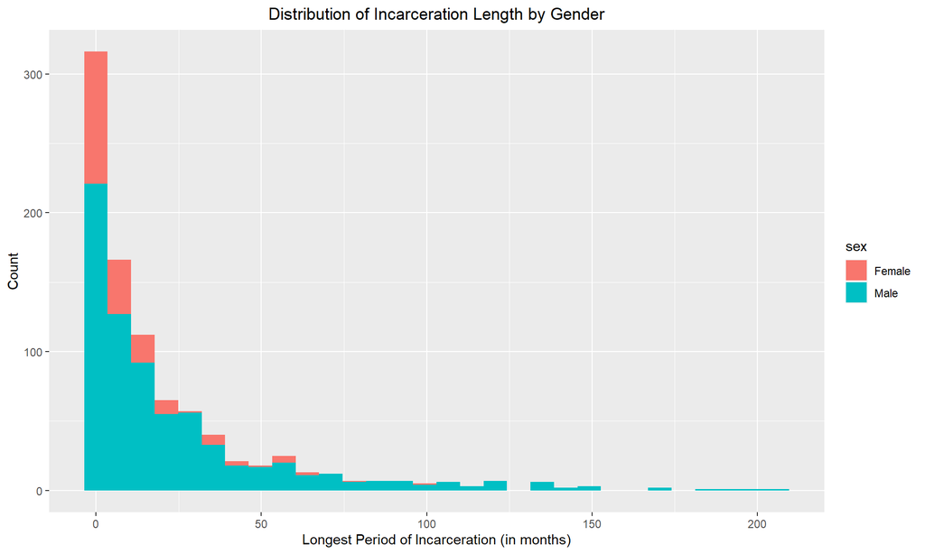

The tabular and graphical summaries for the length of incarceration variable show that, not only are men more likely to have a criminal history than women in this dataset, they are also likely to spend more time in jail when they are incarcerated. The average length of time of incarceration for women is 0.44 months, while the average length of time of incarceration for men is 3.76 months.

### Demographic Variables

#### Condition Limiting Work

**Recoding**

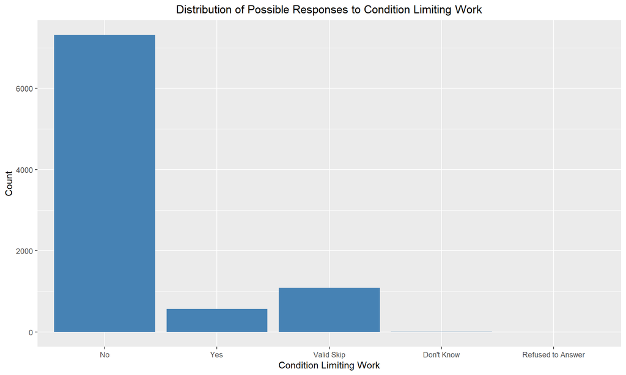

The `condition.limiting.work` variable was further recoded to change the values for which there was a “Valid Skip” to “No” because, based on the codebook, participants might not have been brought to answer this question if there was no previous indication that they might have some condition that would limit them from working. The other two categories, “Don’t Know” and “Refused to Answer” were recoded as “NA”, as these two categories don’t have a useful interpretation in the context of the rest of the variable.

With these adjustments to the `condition.limiting.work` variable, here is the adjusted bar graph of the breakdown in the presence of a work-limiting condition by gender:

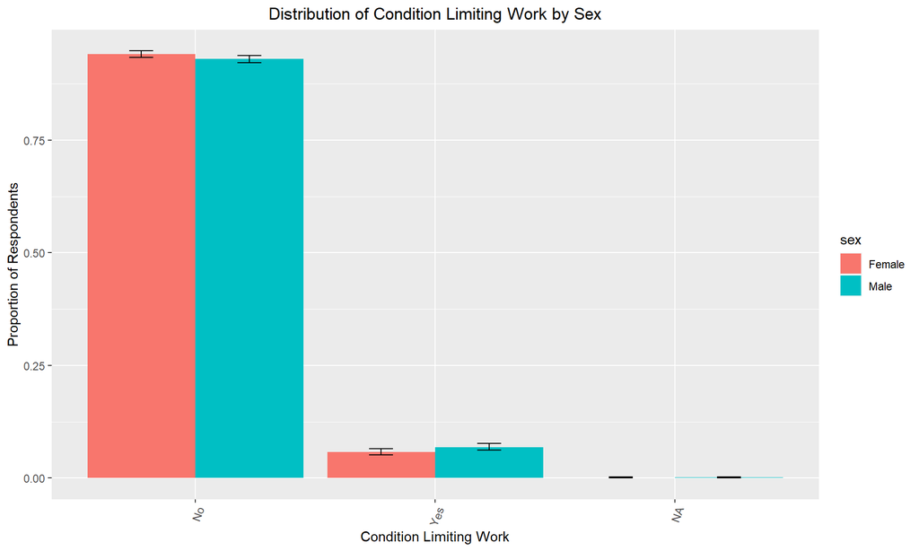

Distribution of Condition Limiting Work by Sex

| Sex | Count | Has a Work-Limiting Condition | Proportion With A Work-Limiting Condition |
| --- | --- | --- | --- |
| Female | 4,385 | 254 | 0.058 |
| Male | 4,599 | 316 | 0.069 |

Both the graphical and tabular summaries show that the majority of the respondents do not have a condition limiting work. Additionally, there appears to be a roughly equal proportion of men and women with work-limiting conditions. 5.79% of women had a work-limiting condition, while 6.87% of men had a work-limiting condition. This might signal that the effect of the this variable on differences in income by gender may not be substantial.

#### Age

**Recoding**

No recoding was required for the age variable because all respondents to the survey provided a response to the question from which this variable is generated.

**Graphical & Tabular Summary**

| sex | Overall Count | Mean Age (in 2017) |
| --- | --- | --- |
| Female | 4385 | 34.00 |
| Male | 4599 | 33.98 |

From this tabular summary, we can see that both men and women have approximately the same mean age of 34. The age value that is used in this analysis is calculated by adding 20 in the participants age in 1997. This new age variable was created to be in line with the year from which the outcome variable, `income`, was calculated.

| Sex | Age in 2017 | Count | Proportion |
| --- | --- | --- | --- |
| Female | 32 | 860 | 0.196 |
| Female | 33 | 873 | 0.199 |
| Female | 34 | 888 | 0.203 |
| Female | 35 | 927 | 0.211 |
| Female | 36 | 837 | 0.191 |
| Male | 32 | 911 | 0.198 |
| Male | 33 | 934 | 0.203 |
| Male | 34 | 953 | 0.207 |
| Male | 35 | 947 | 0.206 |
| Male | 36 | 854 | 0.186 |

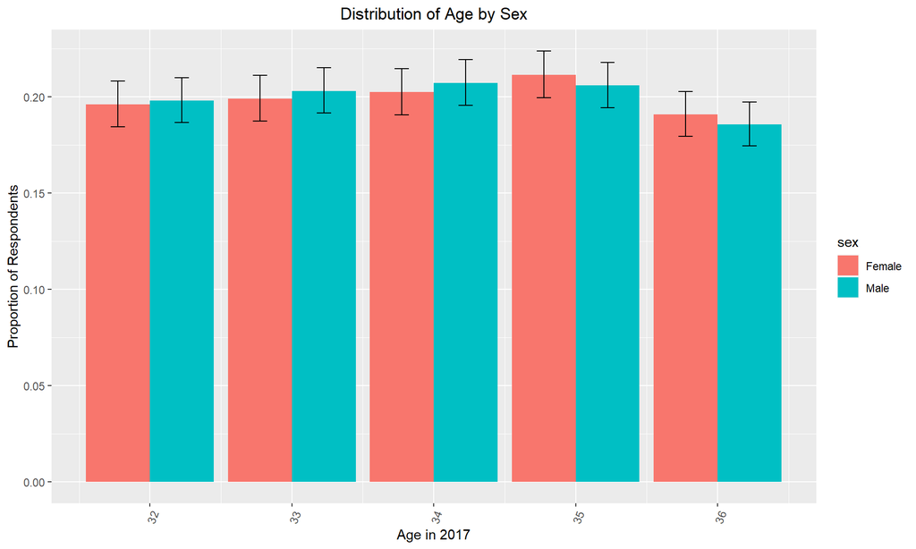

From the bar graphs and the tabular summary, we can observe that the breakdown of age is approximately the same between men and women. Sex does not appear to have an influence on the distribution of age in the dataset.

#### Race/Ethnicity

To begin initially exploring the `race` variable, we created a tabular summary of racial/ethnic background by sex. This tells us if the sample we are working with was properly randomized on the `race` variable.

Breakdown of Race by Sex

| Sex | Race | Count | Proportion |
| --- | --- | --- | --- |
| Female | Non-Black/ Non-Hispanic | 2,252 | 0.5135690 |
| Female | Black | 1,166 | 0.2659065 |
| Female | Hispanic | 924 | 0.2107184 |
| Female | Mixed Race (Non Hispanic) | 43 | 0.0098062 |
| Male | Non-Black/ Non-Hispanic | 2,413 | 0.5246793 |
| Male | Black | 1,169 | 0.2541857 |
| Male | Hispanic | 977 | 0.2124375 |
| Male | Mixed Race (Non Hispanic) | 40 | 0.0086975 |

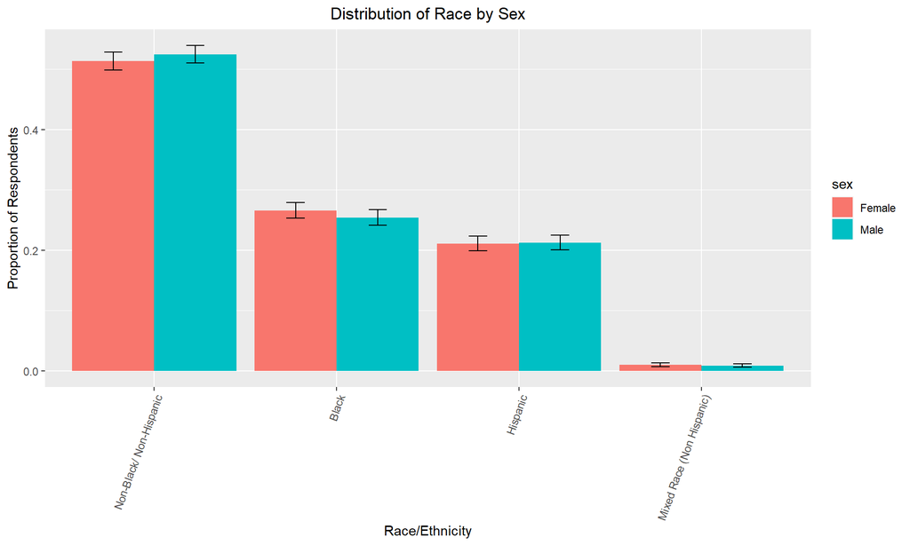

As we can see from the bar chart and tabular summary the distribution of race/ethnicity is quite similar between men and women.

Now that we have a general idea of how the race variable breaks down by sex, we can explore this variable a little further. In order to get a general idea of how racial background effects income we created some buckets to place respondents in. We created a “0 - 5000” for those with very little or no income, and a “5000 - 20000” bucket to get an idea of whose income places them below the poverty line. After that, we used 10,000 ranges up to over 100,000 dollars which we set as our topcoded bucket.

Distribution of Income by Race and Sex

| race | sex | Count | Unknown | $0 - $5,000 | 5,001 - $20,000 | $20,001 - $30,000 | $30,001 - $40,000 | $40,001 - $50,000 | $50,001 - $60,000 | $60,001 - $70,000 | $70,001 - $80,000 | $80,001 - $90,000 | $90,001 - $100,000 | $100,001+ |
| --- | --- | --- | --- | --- | --- | --- | --- | --- | --- | --- | --- | --- | --- | --- |
| Non-Black/ Non-Hispanic | Female | 2252 | 987 | 82 | 217 | 196 | 195 | 168 | 117 | 73 | 65 | 39 | 32 | 81 |
| Non-Black/ Non-Hispanic | Male | 2413 | 944 | 29 | 113 | 163 | 215 | 205 | 154 | 143 | 105 | 74 | 67 | 201 |
| Black | Female | 1166 | 497 | 52 | 144 | 143 | 123 | 89 | 51 | 29 | 11 | 4 | 6 | 17 |
| Black | Male | 1169 | 584 | 42 | 108 | 108 | 99 | 86 | 33 | 29 | 29 | 15 | 12 | 24 |
| Hispanic | Female | 924 | 410 | 32 | 103 | 104 | 93 | 69 | 47 | 20 | 22 | 10 | 4 | 10 |
| Hispanic | Male | 977 | 435 | 15 | 62 | 59 | 90 | 93 | 67 | 42 | 32 | 24 | 19 | 39 |
| Mixed Race (Non Hispanic) | Female | 43 | 21 | 0 | 6 | 4 | 2 | 4 | 2 | 1 | 1 | 0 | 1 | 1 |
| Mixed Race (Non Hispanic) | Male | 40 | 15 | 0 | 4 | 3 | 3 | 1 | 5 | 2 | 0 | 2 | 3 | 2 |

We can see that the counts are generally pretty varied but it’s hard to tell proportionally if income distribution is even across different racial backgrounds. To make variations in the dataset easier to see, we converted all of our counts into proportions of the total of each racial group.

**Next, we calculated the proportions:**

Distribution of Income by Race and Sex (As Proportions)

| race | sex | Unknown | $0 - $5,000 | $5,001 - $20,000 | $20,001 - $30,000 | $30,001 - $40,000 | $40,001 - $50,000 | $50,001 - $60,000 | $60,001 - $70,000 | $70,001 - $80,000 | $80,001 - $90,000 | $90,001 - $100,000 | Over100k |
| --- | --- | --- | --- | --- | --- | --- | --- | --- | --- | --- | --- | --- | --- |
| Non-Black/ Non-Hispanic | Female | 0.44 | 0.04 | 0.10 | 0.09 | 0.09 | 0.07 | 0.05 | 0.03 | 0.03 | 0.02 | 0.01 | 0.04 |
| Non-Black/ Non-Hispanic | Male | 0.39 | 0.01 | 0.05 | 0.07 | 0.09 | 0.08 | 0.06 | 0.06 | 0.04 | 0.03 | 0.03 | 0.08 |
| Black | Female | 0.43 | 0.04 | 0.12 | 0.12 | 0.11 | 0.08 | 0.04 | 0.02 | 0.01 | 0.00 | 0.01 | 0.01 |
| Black | Male | 0.50 | 0.04 | 0.09 | 0.09 | 0.08 | 0.07 | 0.03 | 0.02 | 0.02 | 0.01 | 0.01 | 0.02 |
| Hispanic | Female | 0.44 | 0.03 | 0.11 | 0.11 | 0.10 | 0.07 | 0.05 | 0.02 | 0.02 | 0.01 | 0.00 | 0.01 |
| Hispanic | Male | 0.45 | 0.02 | 0.06 | 0.06 | 0.09 | 0.10 | 0.07 | 0.04 | 0.03 | 0.02 | 0.02 | 0.04 |
| Mixed Race (Non Hispanic) | Female | 0.49 | 0.00 | 0.14 | 0.09 | 0.05 | 0.09 | 0.05 | 0.02 | 0.02 | 0.00 | 0.02 | 0.02 |
| Mixed Race (Non Hispanic) | Male | 0.38 | 0.00 | 0.10 | 0.07 | 0.07 | 0.03 | 0.12 | 0.05 | 0.00 | 0.05 | 0.07 | 0.05 |

#### Marital Status

In our discussions of potential variables, marital status quickly emerged as an important aspect to consider. For this data, we used the 2011 marital status responses. Since there is no way to determine the marital status of those not interviewed or those who skipped the question, we set those values to NA.

Distribution of Marital Status by Sex

| Sex | Marital Status | Total Count |
| --- | --- | --- |
| Female | Never-marrried | 1,307 |
| Female | Married | 1,636 |
| Female | Separated | 79 |
| Female | Divorced | 393 |
| Female | Widowed | 19 |
| Male | Never-marrried | 1,459 |
| Male | Married | 1,430 |
| Male | Separated | 75 |
| Male | Divorced | 270 |
| Male | Widowed | 4 |

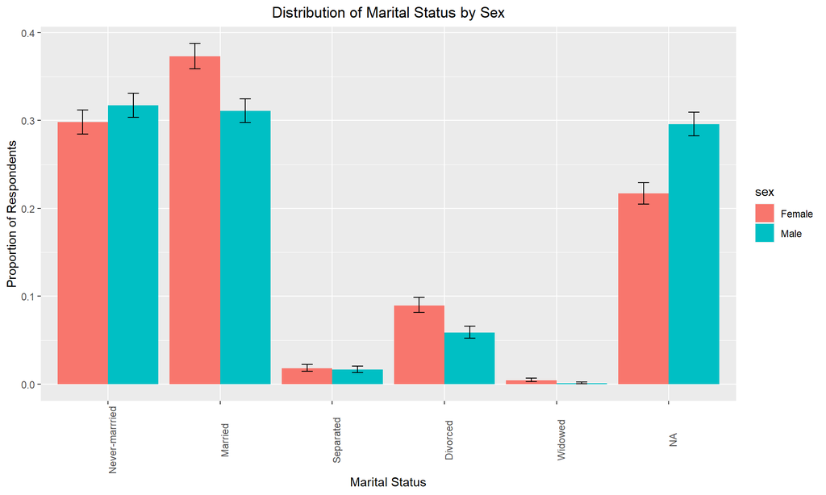

It appears from our plot that more women are both married and divorced than men. Based on the error bars, the differences for these two marital statuses appear to be statistically significant.

#### Citizenship

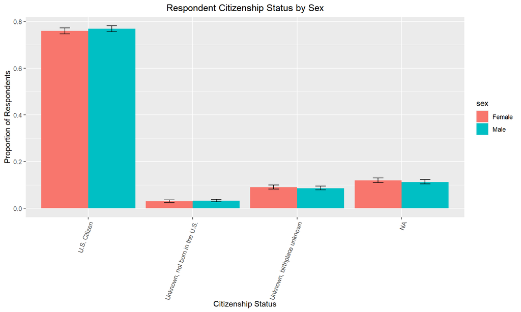

Distribution of Citizenship by Sex

| Sex | Citizenship Status | Count | Proportion of Total |
| --- | --- | --- | --- |
| Female | U.S. Citizen | 3,331 | 0.37 |
| Female | Unknown, not born in the U.S. | 132 | 0.01 |
| Female | Unknown, birthplace unknown | 398 | 0.04 |
| Female | NA | 524 | 0.06 |
| Male | U.S. Citizen | 3,538 | 0.39 |
| Male | Unknown, not born in the U.S. | 147 | 0.02 |
| Male | Unknown, birthplace unknown | 396 | 0.04 |
| Male | NA | 518 | 0.06 |

The tabular summary shows that 76% of respondents are U.S. citizens. Furthermore, the graphical summary suggests that a roughly equal proportion of men and women are U.S. citizens.

#### Urban/Rural Residence

Another demographic variable we chose identifies the respondent’s residence type when they were 12. This is categorized as either urban or rural. The setting in which the respondent grew up could limit the resources available to them, thereby impacting their future income potential.

Distribution of Urban/Rural Residence by Sex

| Sex | Urban/Rural Residence | Count | Proportion |
| --- | --- | --- | --- |
| Female | Urban | 2,547 | 0.28 |
| Female | Rural | 703 | 0.08 |
| Female | Unknown | 32 | 0.00 |
| Female | NA | 1,103 | 0.12 |
| Male | Urban | 2,680 | 0.30 |
| Male | Rural | 781 | 0.09 |
| Male | Unknown | 43 | 0.00 |
| Male | NA | 1,095 | 0.12 |

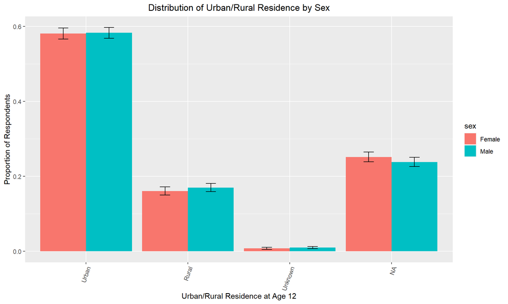

58% of respondents lived in an urban area at the age of 12. There are no patterns in the data in terms of sex - the type of residence at age 12 was evenly divided between men and women.

**ANOVA to Test the Association Between Residence Type and Income**

```
##                       Df        Sum Sq    Mean Sq F value Pr(>F)
## urban.status.age.12    1     231326956  231326956   0.135  0.713
## Residuals           3885 6644997487306 1710424064
## 5097 observations deleted due to missingness
```

```
##                       Df        Sum Sq   Mean Sq F value Pr(>F)
## urban.status.age.12    2     419412992 209706496    0.25  0.779
## Residuals           3820 3201037267016 837967871
## 5040 observations deleted due to missingness
```

Respondents with “NA” or “Unknown” residence were reassigned as NA for the purposes of statistical analysis. ANOVA results show there is no statistically significant relationship between the type of residence (urban vs. rural) at age 12 and total income later in life. These results hold for subsets of the data both with and without topcoded income values included.

#### Number of Children under 6 in the Household

Distribution of the Number of Children by Sex

| Sex | Number of Children Under the Age of 6 | Total Count |
| --- | --- | --- |
| Female | 0 | 1,955 |
| Female | 1 | 1,150 |
| Female | 2 | 467 |
| Female | 3 | 84 |
| Female | 4 | 10 |
| Female | 5 | 1 |
| Male | 0 | 2,605 |
| Male | 1 | 710 |
| Male | 2 | 352 |
| Male | 3 | 57 |
| Male | 4 | 5 |

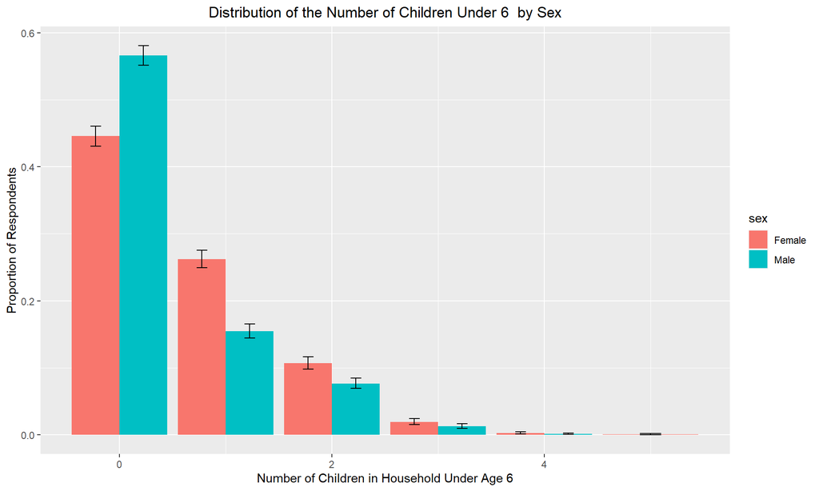

While it is true that 0 children in the household under age 6 was the highest category for both men and women in 2011, it looks like many more men had 0 children under 6 in the household than women. To be sure this is a statistically significant difference, we ran a t-test.

```
##
##  Welch Two Sample t-test
##
## data:  num.children.under.6 by sex
## t = 12.146, df = 7299.8, p-value < 2.2e-16
## alternative hypothesis: true difference in means is not equal to 0
## 95 percent confidence interval:
##  0.1835647 0.2542239
## sample estimates:
## mean in group Female   mean in group Male
##            0.6493046            0.4304103
```

The results of the t-test show that there is a statiscally significant difference in the mean number of children that men and women have. Specifically, women are more likely to have more children under the age of 6 in their household than men.

### Education-Related Variables

#### Highest Degree Earned by Respondent

**Recoding**

The two negative values for this variable correspond to “Non-Interview” and “Invalid Skip”, which both don’t have a useful interpretation. Therefore, the variable was recoded accordingly to set entries with these responses to “NA”.

Distribution of Highest Degree Earned by Sex

| Sex | Highest Degree Earned | Count | Proportion |
| --- | --- | --- | --- |
| Female | No Degree Earned | 335 | 0.08 |
| Female | GED | 373 | 0.09 |
| Female | High School Diploma | 1555 | 0.35 |
| Female | Associate | 300 | 0.07 |
| Female | Bachelors | 822 | 0.19 |
| Female | Masters | 217 | 0.05 |
| Female | PhD | 9 | 0.00 |
| Female | Professional Degree (DDS, JD, MD) | 38 | 0.01 |
| Female | NA | 736 | 0.17 |
| Male | No Degree Earned | 413 | 0.09 |
| Male | GED | 544 | 0.12 |
| Male | High School Diploma | 1721 | 0.37 |
| Male | Associate | 232 | 0.05 |
| Male | Bachelors | 641 | 0.14 |
| Male | Masters | 124 | 0.03 |
| Male | PhD | 4 | 0.00 |
| Male | Professional Degree (DDS, JD, MD) | 35 | 0.01 |
| Male | NA | 885 | 0.19 |

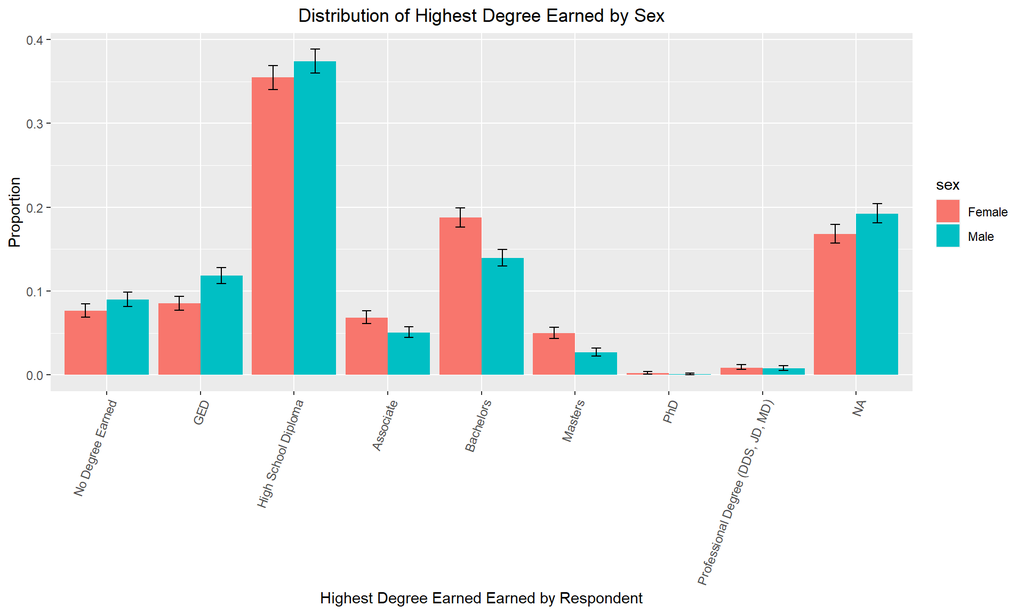

#### Highest Grade Completed by Residential Dad

The following summaries investigate the highest level of education completed by the respondent’s residential parents.

Distribution of Dad’s Highest Level of Education

| School Completed by Residential Dad | Count | Proportion |
| --- | --- | --- |
| Some elementary school | 120 | 0.013 |
| Completed elementary school | 51 | 0.006 |
| Some middle school | 219 | 0.024 |
| Completed middle school | 117 | 0.013 |
| Some high school | 658 | 0.073 |
| Completed high school | 1,917 | 0.213 |
| 1-2 years of college | 1,065 | 0.119 |
| 3-4 years of college | 944 | 0.105 |
| 5-6 years of college | 374 | 0.042 |
| 7 years of college | 86 | 0.010 |
| 8 years of college or more | 153 | 0.017 |
| NA | 3,280 | 0.365 |

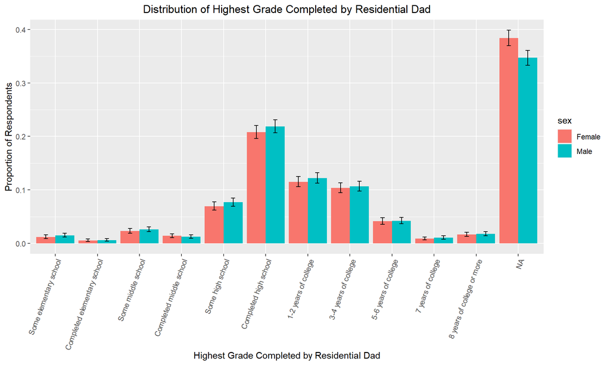

**Key Takeaways**

21.34% of residential fathers completed high school and 11.85% of completed 1-2 years of college. Another 10.51% completed 3-4 years of college.

#### Highest Grade Completed by Residential Mom

Distribution of Mom’s Highest Level of Education

| School Completed by Residential Mom | Count | Proportion |
| --- | --- | --- |
| Some elementary school | 136 | 0.015 |
| Completed elementary school | 54 | 0.006 |
| Some middle school | 288 | 0.032 |
| Completed middle school | 183 | 0.020 |
| Some high school | 1,150 | 0.128 |
| Completed high school | 2,870 | 0.319 |
| 1-2 years of college | 1,635 | 0.182 |
| 3-4 years of college | 1,153 | 0.128 |
| 5-6 years of college | 409 | 0.046 |
| 7 years of college | 38 | 0.004 |
| 8 years of college or more | 89 | 0.010 |
| NA | 979 | 0.109 |

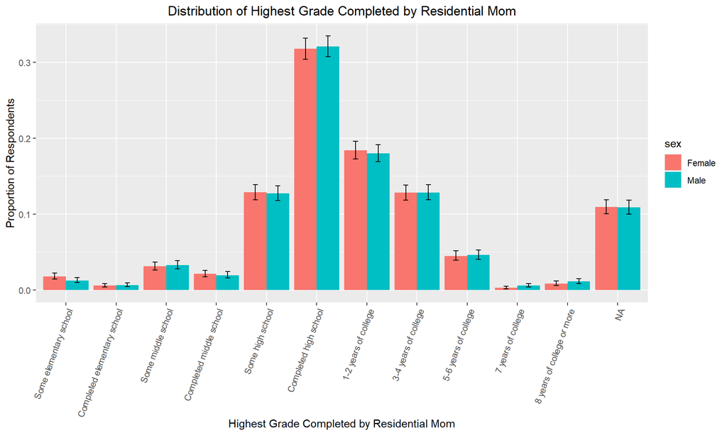

**Key Takeaways**

Notably, there are more “Valid Skip” or “NA” responses for the residential dads and this is worth further review. 36.51% of respondents don’t have a valid datapoint for their residential dad.

When we compare the average number of school years completed by the residential parents, they are roughly equal. On average, residential dads completed 12.88 years of school, which correlates to completing high school. By comparison, residential moms completed an average of 12.53 years of school.

#### Summary Graphs for Education Variables & ANOVA tests

The following box plots compare the highest degree earned by respondents on the x-axis and the number of school years completed by the residential parent on the y-axis. As the degree level advances towards Bachelors, Masters, Professional, and PhD degrees, the median education level of the parent also increases. These trends are apparent for both the residential mothers and fathers.

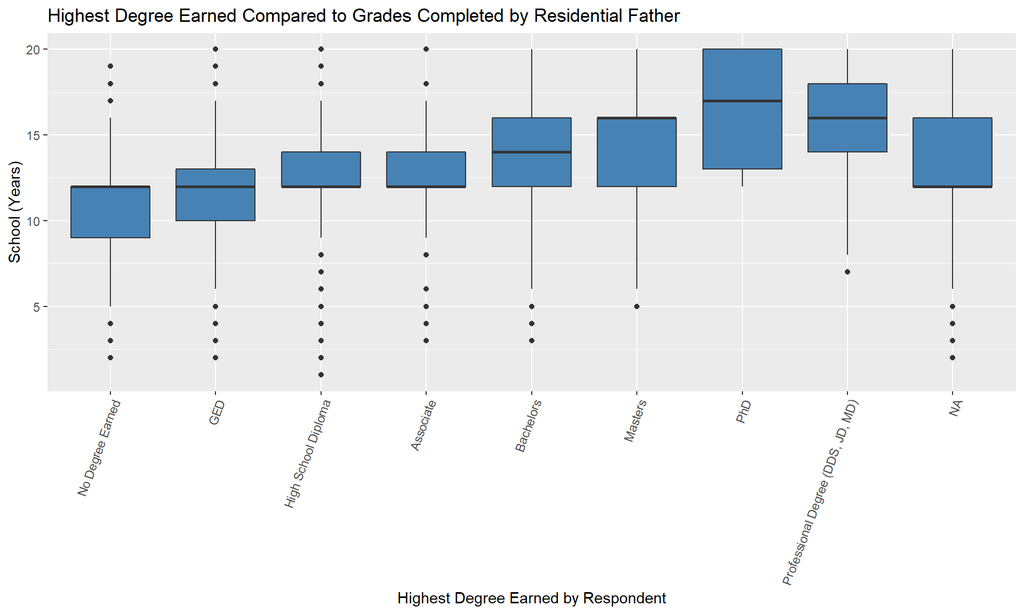

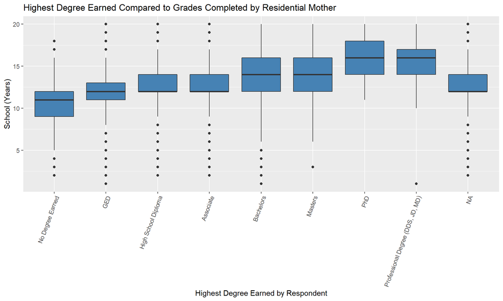

```
##                                           Df        Sum Sq      Mean Sq F value
## residential.mom.highest.grade.completed    1  312289526319 312289526319   193.5
## Residuals                               4586 7401417931939   1613915816
##                                         Pr(>F)
## residential.mom.highest.grade.completed <2e-16 ***
## Residuals
## ---
## Signif. codes:  0 '***' 0.001 '**' 0.01 '*' 0.05 '.' 0.1 ' ' 1
## 4396 observations deleted due to missingness
```

```
##                                           Df        Sum Sq      Mean Sq F value
## residential.dad.highest.grade.completed    1  259615249095 259615249095     145
## Residuals                               3346 5992614670032   1790978682
##                                         Pr(>F)
## residential.dad.highest.grade.completed <2e-16 ***
## Residuals
## ---
## Signif. codes:  0 '***' 0.001 '**' 0.01 '*' 0.05 '.' 0.1 ' ' 1
## 5636 observations deleted due to missingness
```

```
##                                           Df        Sum Sq      Mean Sq F value
## residential.mom.highest.grade.completed    1  110850655549 110850655549   135.9
## Residuals                               4474 3649568595205    815728340
##                                         Pr(>F)
## residential.mom.highest.grade.completed <2e-16 ***
## Residuals
## ---
## Signif. codes:  0 '***' 0.001 '**' 0.01 '*' 0.05 '.' 0.1 ' ' 1
## 4387 observations deleted due to missingness
```

```
##                                           Df        Sum Sq     Mean Sq F value
## residential.dad.highest.grade.completed    1   83838528574 83838528574   98.25
## Residuals                               3247 2770712809871   853314694
##                                         Pr(>F)
## residential.dad.highest.grade.completed <2e-16 ***
## Residuals
## ---
## Signif. codes:  0 '***' 0.001 '**' 0.01 '*' 0.05 '.' 0.1 ' ' 1
## 5614 observations deleted due to missingness
```

ANOVA results show that there is a statistically significant difference between respondents income and the education obtained by their residential parents. These results hold for both residential mother and father and when topcoded income values have been removed from the dataset.

Before analyzing the data, we hypothesized a sex-based relationship between a residential parent’s education and the highest degree obtained by sex. For example, we considered that the highest degree obtained by a female respondent would depend on the level of education completed by her residential mother. However, the data exploration did not reveal these expected patterns.

### Findings

#### Group 1: Criminal History Variables

Given that both of the variables related to criminal history capture similar information, we conducted a test of collinearity on the `longest.length.incarc.months` and the `num.times.incarc` variables.

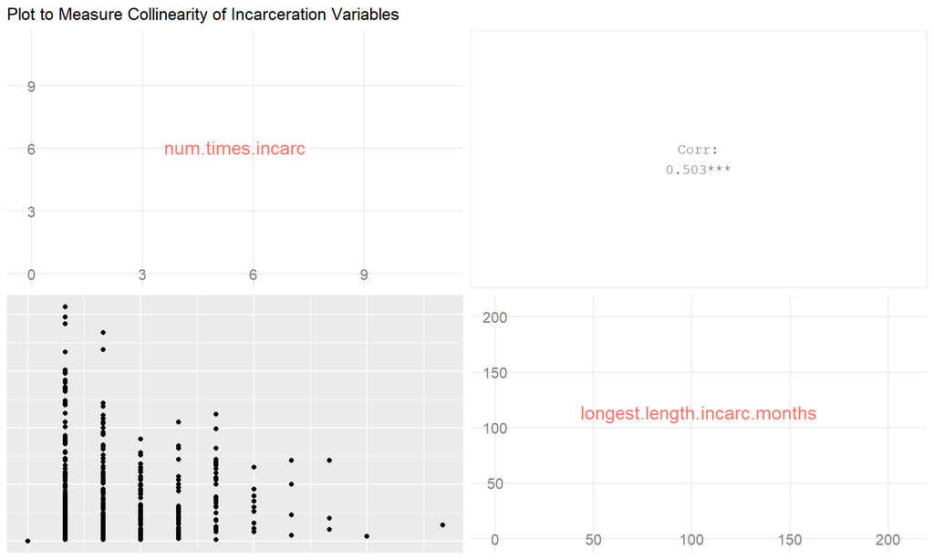

There does not appear to be any strong collinearity between the incarceration-related variables.

After testing for collinearity, we also plotted income against the two criminal history variables to get a sense for how they varied with income.

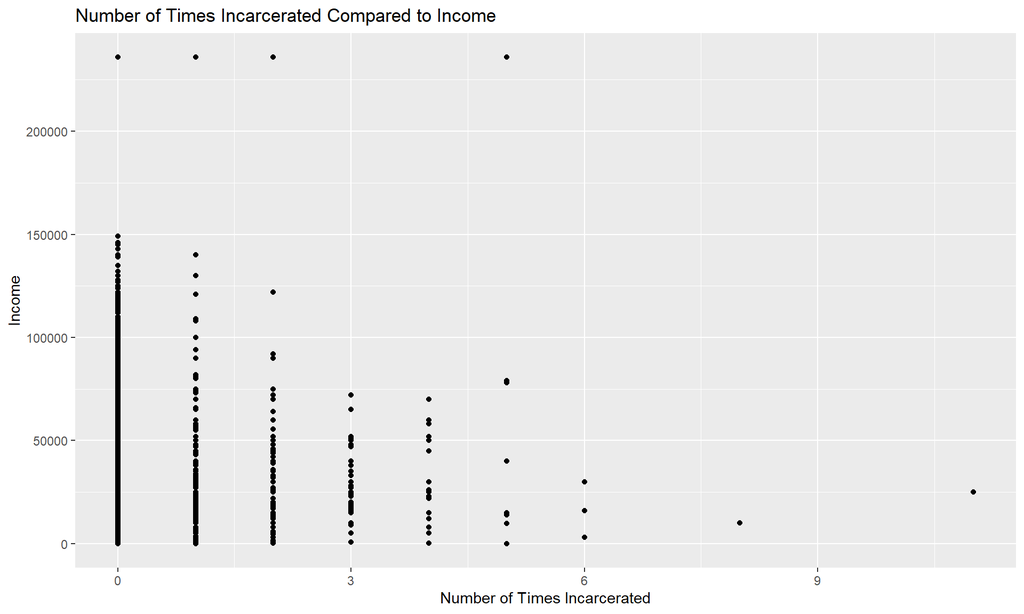

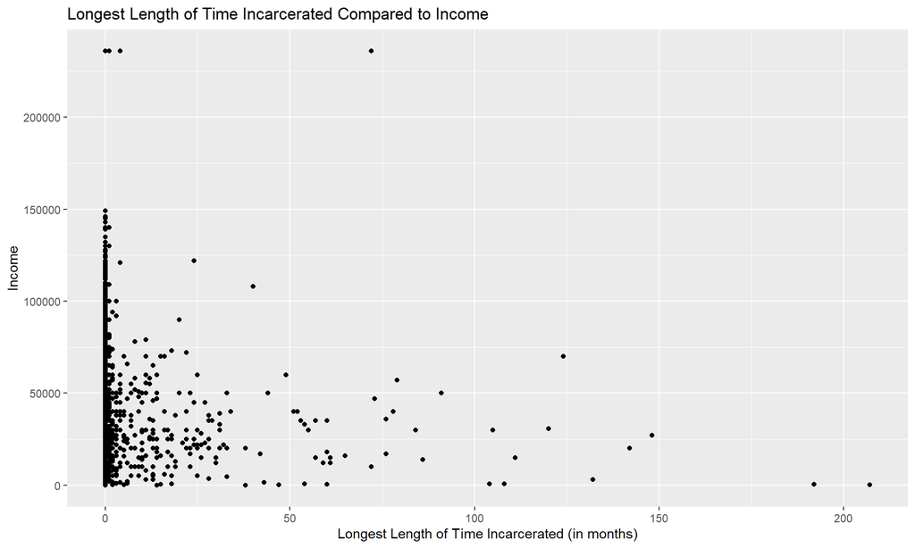

While the incarceration-related variables do not appear to be collinear, there does appear to be some association between each of the variables and the income variable. Particularly, as the number of times someone has been incarcerated increases, their income appears to decline. Additionally, as the length of a participant’s longest period of incarceration increases, their income also appears to decline.

Despite these general trends, there do appear to be a few outliers in the dataset. Particularly, we see that there is an respondent whose longest length of time incarceration is greater than 50 months (approximately 4 years) but they made more than $200,000 in income in 2017, compared to other participants with the same longest length of incarceration, whose income averages to around 50,000 dollars. The effect of these outliers in the incarceration variables is explored further in the analysis distinguishing between when the `income` outcome variable is topcoded and when it is not topcoded.

#### Group 2: Education Variables

We were also interested in seeing if the highest grade completed by the residential mother and father of the participants were in any way collinear, given that these variables capture similar types of information. One could expect that as one residential parent has more education, the other parent is more likely to have a comparable level of education.

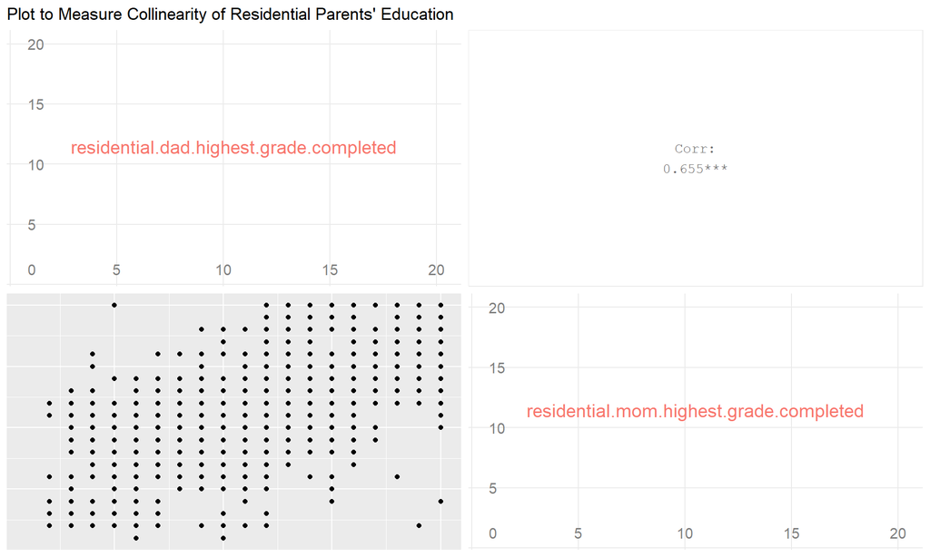

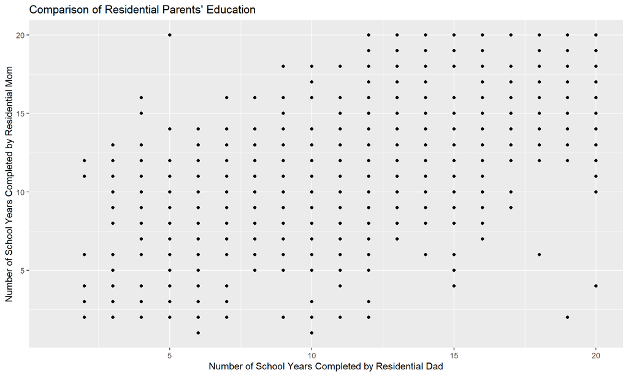

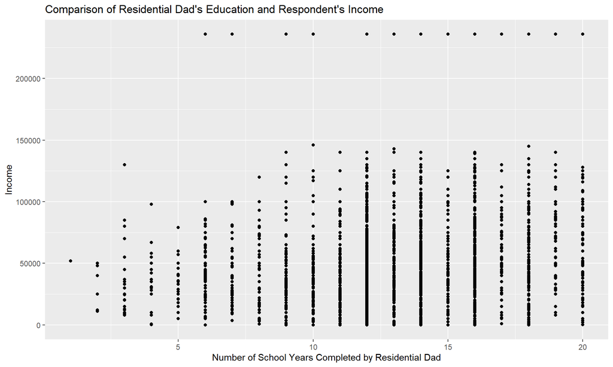

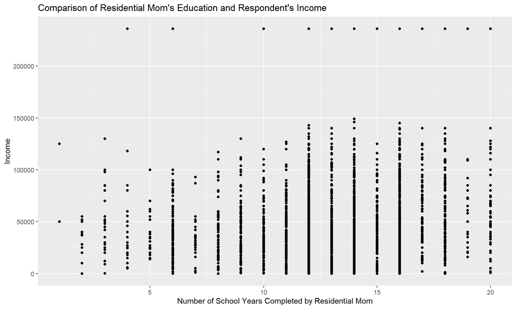

While there is an association of 0.66 between the educational levels of parents, there does not appear to be strong collinearity in the parental education variables. As discussed in analysis of education variables, the educational achievements of residential parents impact the total income of respondents.

There are notable outliers, however. There are a number of respondents who reported over 100,000 dollars in income while their residential parent(s) completed less than 10 years of school (this corresponds to not completing high school).

### Linear Regression Models & Associated Diagnostic Plots

#### Model 1: Regressing Income on All Variables in Our Subset

|  | Estimate | Std. Error | t value | Pr(>\|t\|) |
| --- | --- | --- | --- | --- |
| (Intercept) | -17234 | 20175 | -0.85 | 0.3931 |
| sexMale | 21434 | 1629 | 13.16 | 0.0000 |
| num.times.incarc | -3239 | 1921 | -1.69 | 0.0919 |
| longest.length.incarc.months | -158 | 141 | -1.12 | 0.2636 |
| condition.limiting.workYes | -6593 | 3706 | -1.78 | 0.0754 |
| citizenshipUnknown, not born in the U.S. | 10165 | 4603 | 2.21 | 0.0273 |
| citizenshipUnknown, birthplace unknown | 14665 | 3297 | 4.45 | 0.0000 |
| urban.status.age.12Rural | -3392 | 1889 | -1.80 | 0.0727 |
| residential.dad.highest.grade.completed | 237 | 341 | 0.69 | 0.4875 |
| residential.mom.highest.grade.completed | 1313 | 363 | 3.62 | 0.0003 |
| raceBlack | -3664 | 2328 | -1.57 | 0.1156 |
| raceHispanic | -1645 | 2536 | -0.65 | 0.5166 |
| raceMixed Race (Non Hispanic) | -14102 | 9520 | -1.48 | 0.1386 |
| num.children.under.6 | -626 | 1105 | -0.57 | 0.5709 |
| highest.degree.earnedGED | 2338 | 5101 | 0.46 | 0.6468 |
| highest.degree.earnedHigh School Diploma | 9365 | 4350 | 2.15 | 0.0314 |
| highest.degree.earnedAssociate | 17845 | 5055 | 3.53 | 0.0004 |
| highest.degree.earnedBachelors | 33999 | 4586 | 7.41 | 0.0000 |
| highest.degree.earnedMasters | 36818 | 5275 | 6.98 | 0.0000 |
| highest.degree.earnedPhD | 52522 | 12805 | 4.10 | 0.0000 |
| highest.degree.earnedProfessional Degree (DDS, JD, MD) | 128980 | 7990 | 16.14 | 0.0000 |
| marital.statusMarried | 11246 | 1838 | 6.12 | 0.0000 |
| marital.statusSeparated | 1851 | 7060 | 0.26 | 0.7932 |
| marital.statusDivorced | 4990 | 3025 | 1.65 | 0.0991 |
| marital.statusWidowed | 14510 | 16965 | 0.86 | 0.3925 |
| age.in.2017 | 423 | 572 | 0.74 | 0.4592 |

From this initial linear regression model, we can observe that, holding all other variables constant, men make 21,434 dollars more than their female counterparts. This coefficient estimate is statistically significant, with a p-value of 3.6433317^{-38}.

Both of the criminal history-related variables, `num.times.incarc` and `longest.length.incarc.months` both appear to be negatively correlated with income. As the number of times an individual has been incarcerated increases and as the length of a respondent’s longest period of incarceration increases, their income appears to decline. Neither of these coefficients appear to be statistically significant at a level of 0.05.

Respondents with an unknown birtplace and those who were not born in the U.S. appear to make more money on average, holding all other variables constant, than their counterparts who are U.S. citizens. A critical fact to note, however, is that individuals with an unknown birthplace make up only 794 of the respondents, so this effect could be overstated given the small sample size, relative to the number of respondents in the study who are citizens.

With regard to impact of race on income, Black, Hispanic, and Mixed Race (Non Hispanic) respondents appear to, on average, make less than their Non-Black, Non-Hispanic counterparts. However, this difference in earnings does not appear to be statistically significant.

The education-related variables appear to have the most number of statistically significant associations with income. As the level of the highest degree that individuals have received increases, their earnings also appear to increase. Study participants with a Professional Degree (DDS, JD, or MD) appear to make, on average, 128,980 dollars more than their counterparts who have not earned a degree. This coefficient estimate is statistically significant, with a p-value of 0.

Finally, individuals who are married appear to make, on average, 11,246 dollars more than their counterparts who are not married. This difference is statistically significant in this linear regression model, with a p-value of 1.1059217^{-9}.

From the R-squared value for this linear regression model, only about 30% of the variance in the data is explained by the model. To conduct further analysis on model fit, we also ran the `plot()` function to analyze the diagnostic plots for this model.

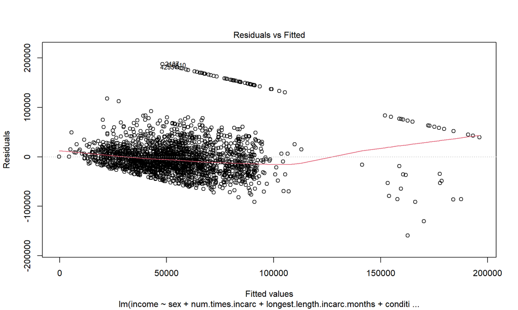

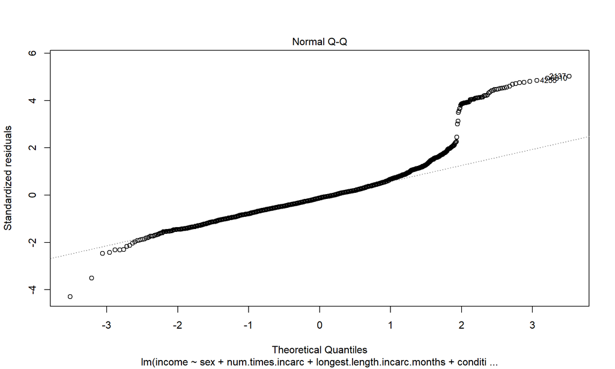

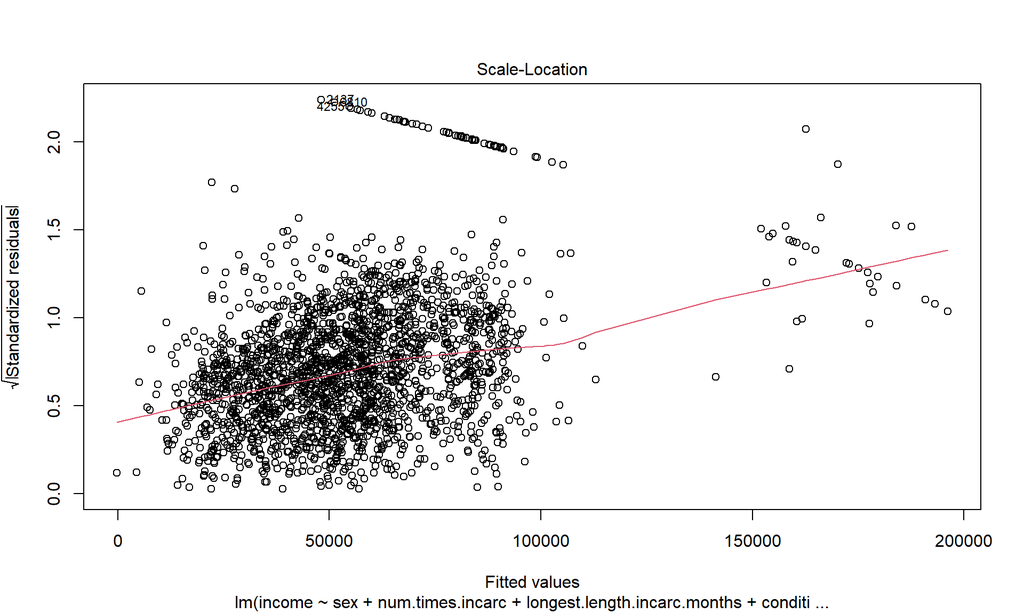

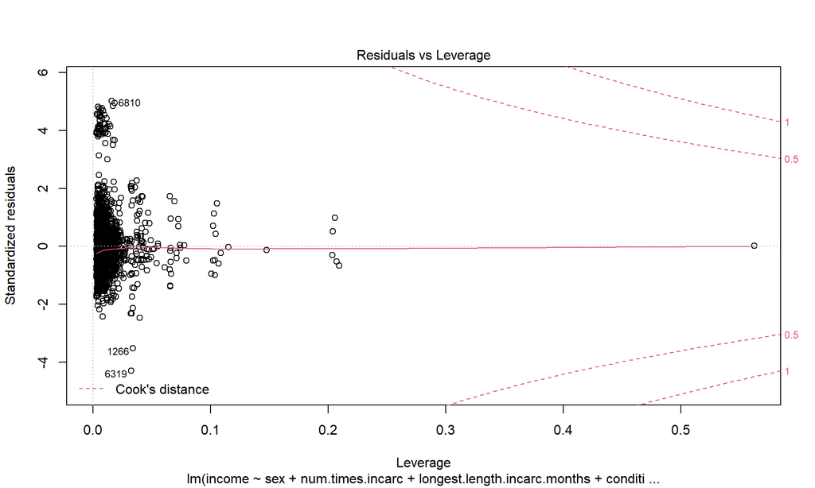

**Residual vs Fitted Plot**

The residual vs. fitted plot shows that, for the lower fitted values, there is some clustering around 0 but as the fitted values increase, there is a greater deviation away from a residual of 0. This could be caused, in part, by the top-coding of the income variable. Furthermore, as we observed from the earlier tabular and graphical summaries, the majority of respondents make around $50,000, therefore there are more observations on which to calculate the residuals in this part of the income spectrum. This isn’t the case, however, with the observations in the top income tier of the dataset.

**Normal QQ Plot**

The normal QQ plot shows a similar trend to the residual vs. fitted plot graph. For the majority of the curve, the residuals match almost perfectly to the diagonal, demonstrating that these residuals appear to be mostly normally distrbuted. Once we hit of a theoretical quantile of about 2 however, the residuals appear to drastically deviate from the diagonal line. Therefore, in the upper tail of the dataset, the assumption of normality does not appear to hold.

**Scale-Location Plot**

The scale-location plot appears to make a strong case that the assumption of constant variance does not hold for this model. As the fitted values increase, the variance increases steadily. This could also likely to be a side effect of the top-coding of the income variable.

#### Model 2: Addressing the Top-Coding of the Income Variable

The following linear regression is the same as the previous model (referred to as Model #1), where income is regressed on all variables in the subset. The notable exception is that observations with topcoded income are no longer in the subset.

|  | Estimate | Std. Error | t value | Pr(>\|t\|) |
| --- | --- | --- | --- | --- |
| (Intercept) | -8198 | 13740 | -0.60 | 0.5508 |
| sexMale | 16267 | 1108 | 14.68 | 0.0000 |
| num.times.incarc | -2866 | 1334 | -2.15 | 0.0318 |
| longest.length.incarc.months | -133 | 92 | -1.44 | 0.1487 |
| condition.limiting.workYes | -8840 | 2544 | -3.47 | 0.0005 |
| condition.limiting.workValid Skip | -32868 | 26134 | -1.26 | 0.2086 |
| condition.limiting.workDon’t Know | -42908 | 26177 | -1.64 | 0.1013 |
| condition.limiting.workRefused to Answer | 18055 | 26267 | 0.69 | 0.4919 |
| citizenshipUnknown, not born in the U.S. | 5216 | 3175 | 1.64 | 0.1006 |
| citizenshipUnknown, birthplace unknown | 5666 | 2288 | 2.48 | 0.0134 |
| urban.status.age.12Rural | -2608 | 1278 | -2.04 | 0.0414 |
| urban.status.age.12Unknown | -1555 | 5629 | -0.28 | 0.7824 |
| residential.dad.highest.grade.completed | 133 | 230 | 0.58 | 0.5625 |
| residential.mom.highest.grade.completed | 502 | 248 | 2.02 | 0.0431 |
| raceBlack | -4167 | 1571 | -2.65 | 0.0080 |
| raceHispanic | 149 | 1702 | 0.09 | 0.9302 |
| raceMixed Race (Non Hispanic) | -9654 | 6395 | -1.51 | 0.1313 |
| num.children.under.6 | -1161 | 756 | -1.54 | 0.1247 |
| highest.degree.earnedGED | 5012 | 3485 | 1.44 | 0.1505 |
| highest.degree.earnedHigh School Diploma | 11329 | 2971 | 3.81 | 0.0001 |
| highest.degree.earnedAssociate | 20901 | 3453 | 6.05 | 0.0000 |
| highest.degree.earnedBachelors | 28663 | 3138 | 9.13 | 0.0000 |
| highest.degree.earnedMasters | 35334 | 3627 | 9.74 | 0.0000 |
| highest.degree.earnedPhD | 59464 | 8849 | 6.72 | 0.0000 |
| highest.degree.earnedProfessional Degree (DDS, JD, MD) | 66353 | 7218 | 9.19 | 0.0000 |
| highest.degree.earnedNon-Interview | 14490 | 5671 | 2.56 | 0.0107 |
| highest.degree.earnedInvalid Skip | 22933 | 7361 | 3.12 | 0.0019 |
| marital.statusMarried | 7730 | 1249 | 6.19 | 0.0000 |
| marital.statusSeparated | 1276 | 4601 | 0.28 | 0.7815 |
| marital.statusDivorced | 3909 | 2026 | 1.93 | 0.0538 |
| marital.statusWidowed | 3354 | 10734 | 0.31 | 0.7547 |
| marital.statusInvalid Skip | 2705 | 6840 | 0.40 | 0.6925 |
| age.in.2017 | 546 | 388 | 1.41 | 0.1595 |

From this linear regression model, we can observe that, holding all other variables constant, men make 16,267 dollars more than their female counterparts. This coefficient estimate is statistically significant, with a p-value of 9.0663611^{-47}.

The results of this model are very similar to Model #1, with some exceptions. The `num.times.incarc` variable is still negatively associated with income. In this model, unlike in Model #1 however, this relationship is statistically significant. There are some outliers in the comparison of income and criminal history (those with a history of incarceration and very high income). With the removal of these outliers, the model perhaps is better capturing the impact of criminal history on income.

From the R-squared value for this linear regression model, only about 25% of the variance in the data is explained by the model. This R-squared is slightly lower than that of Model #1. To conduct further analysis on model fit, we also ran the `plot()` function to analyze the diagnostic plots for this model.

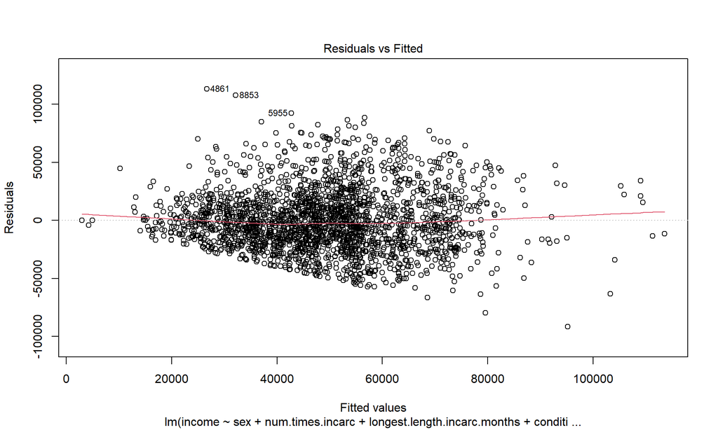

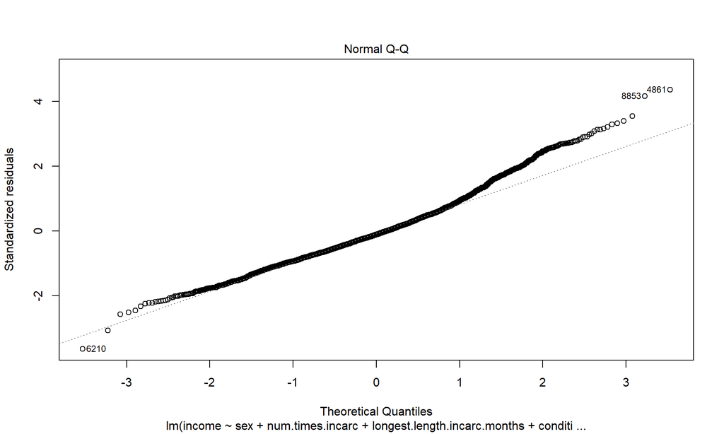

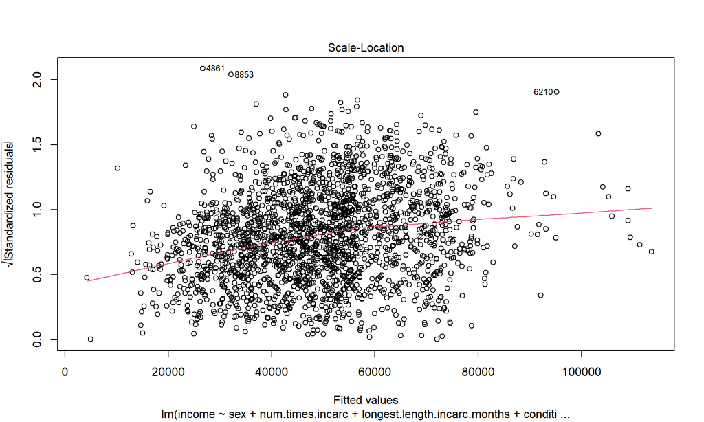

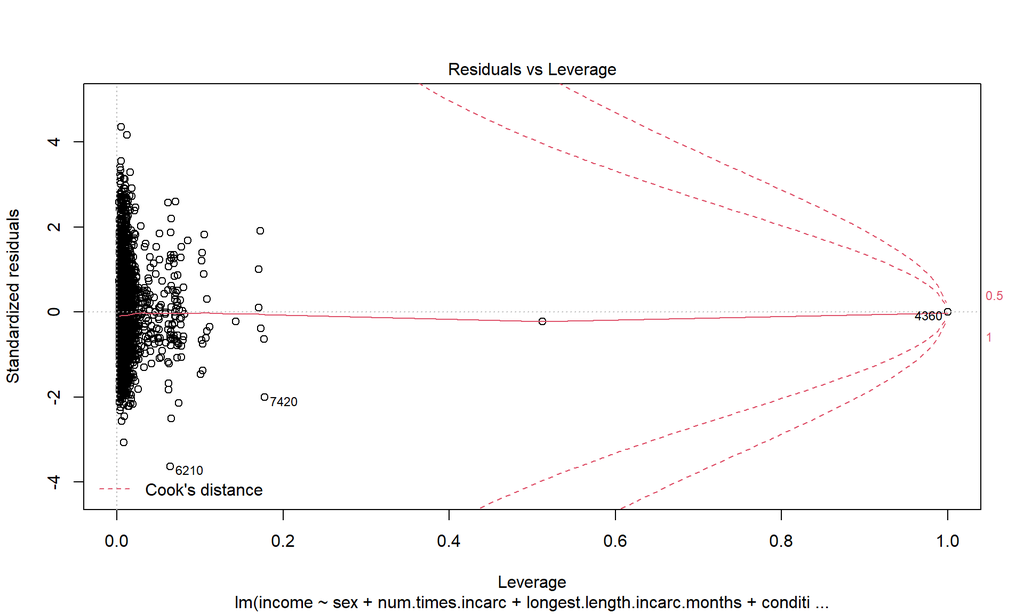

**Residual vs Fitted Plot**

**Normal QQ Plot**

The normal QQ plot shows a similar trend to the residual vs. fitted plot in the first model. Although there are still large deviations in the upper tail, the data in this model appear more normal than in Model #1.

**Scale-Location Plot**

As the fitted values increase, the variance still increases steadily. The slope of the standardized residuals, although not constant, is smaller than the slope in Model #1.

**Outliers & The Residuals vs Leverage Plot**

The residuals vs leverage plot show that the outliers in the first plot persist even with the removal of topcoded income.

Overall, it appears that removing the topcoded income values has addressed some of the non-constant variance from Model #1, but not all of it.

#### Models 3 & 4: Distilling the Impact of Gender & Criminal History on Income

**Adding An Interaction Term between sex and num.times.incarc**

From the tabular and graphical summaries conducted earlier, it was evident that were was a difference in the incarceration rate of respondents in the study based on their gender. Particuarly, more men than women in the study had been incarcerated and, among the population that had been incarcerated, men tended to serve longer sentences than women. With this information, we decided to take a look at the gender differences in income based on criminal history.

|  | Estimate | Std. Error | t value | Pr(>\|t\|) |
| --- | --- | --- | --- | --- |
| (Intercept) | -8230 | 13743 | -0.60 | 0.5493 |
| sexMale | 16305 | 1116 | 14.61 | 0.0000 |
| num.times.incarc | -1663 | 4367 | -0.38 | 0.7034 |
| longest.length.incarc.months | -133 | 92 | -1.44 | 0.1511 |
| condition.limiting.workYes | -8851 | 2545 | -3.48 | 0.0005 |
| condition.limiting.workValid Skip | -32837 | 26139 | -1.26 | 0.2092 |
| condition.limiting.workDon’t Know | -42909 | 26182 | -1.64 | 0.1014 |
| condition.limiting.workRefused to Answer | 18083 | 26273 | 0.69 | 0.4914 |
| citizenshipUnknown, not born in the U.S. | 5230 | 3176 | 1.65 | 0.0998 |
| citizenshipUnknown, birthplace unknown | 5665 | 2289 | 2.47 | 0.0134 |
| urban.status.age.12Rural | -2615 | 1278 | -2.05 | 0.0409 |
| urban.status.age.12Unknown | -1545 | 5630 | -0.27 | 0.7838 |
| residential.dad.highest.grade.completed | 133 | 231 | 0.58 | 0.5651 |
| residential.mom.highest.grade.completed | 503 | 248 | 2.03 | 0.0427 |
| raceBlack | -4157 | 1571 | -2.65 | 0.0082 |
| raceHispanic | 148 | 1703 | 0.09 | 0.9307 |
| raceMixed Race (Non Hispanic) | -9654 | 6396 | -1.51 | 0.1313 |
| num.children.under.6 | -1153 | 757 | -1.52 | 0.1276 |
| highest.degree.earnedGED | 5009 | 3486 | 1.44 | 0.1509 |
| highest.degree.earnedHigh School Diploma | 11314 | 2972 | 3.81 | 0.0001 |
| highest.degree.earnedAssociate | 20896 | 3453 | 6.05 | 0.0000 |
| highest.degree.earnedBachelors | 28654 | 3139 | 9.13 | 0.0000 |
| highest.degree.earnedMasters | 35323 | 3627 | 9.74 | 0.0000 |
| highest.degree.earnedPhD | 59462 | 8850 | 6.72 | 0.0000 |
| highest.degree.earnedProfessional Degree (DDS, JD, MD) | 66356 | 7220 | 9.19 | 0.0000 |
| highest.degree.earnedNon-Interview | 14541 | 5675 | 2.56 | 0.0105 |
| highest.degree.earnedInvalid Skip | 22922 | 7363 | 3.11 | 0.0019 |
| marital.statusMarried | 7734 | 1249 | 6.19 | 0.0000 |
| marital.statusSeparated | 1285 | 4602 | 0.28 | 0.7801 |
| marital.statusDivorced | 3896 | 2026 | 1.92 | 0.0546 |
| marital.statusWidowed | 3372 | 10737 | 0.31 | 0.7535 |
| marital.statusInvalid Skip | 2728 | 6841 | 0.40 | 0.6902 |
| age.in.2017 | 547 | 388 | 1.41 | 0.1593 |
| sexMale:num.times.incarc | -1295 | 4476 | -0.29 | 0.7724 |

From the results of adding this interaction term, we can observe that there is a difference in the impact of incarceration on income depending on the study participants’ gender. Specifically, we see that for women, each additional incarceration results in a 1,663 dollar decline in their income. However, for men, each additional incarceration results in a 2,958 dollar decline in their income. Although these findings are in line with our tabular and graphical summaries for `num.times.incarc`, neither one of these findings is statistically significant.

**Testing the Significance of Adding the Sex * Number of Times Incarcerated Term**

Now that the `sex * num.times.incarc` interaction variable was added to the regression, we also decided to test whether this addition was statistically signfiicant using an ANOVA test.

```
## Analysis of Variance Table
##
## Model 1: income ~ sex + num.times.incarc + longest.length.incarc.months +
##     condition.limiting.work + citizenship + urban.status.age.12 +
##     residential.dad.highest.grade.completed + residential.mom.highest.grade.completed +
##     race + num.children.under.6 + highest.degree.earned + marital.status +
##     age.in.2017
## Model 2: income ~ sex + num.times.incarc + longest.length.incarc.months +
##     condition.limiting.work + citizenship + urban.status.age.12 +
##     residential.dad.highest.grade.completed + residential.mom.highest.grade.completed +
##     race + num.children.under.6 + highest.degree.earned + marital.status +
##     age.in.2017 + sex:num.times.incarc
##   Res.Df           RSS Df Sum of Sq      F Pr(>F)
## 1   2346 1595000619595
## 2   2345 1594943701328  1  56918266 0.0837 0.7724
```

From this analysis, we can see that because the p-value for this test is 0.7723895, we would fail to reject the null hypothesis that there is no income gap between men and women based on the number of times that they are incarcerated. Put simply, the data suggests that the income gap between men and women does not vary based on the number of times an individual has been incarcerated.

**Adding An Interaction Term of Sex * Longest.Length.Incarc.Months**

We also saw from the initial tabular and graphical summaries that men, on average, served longer sentences when they were incarcerated than women. Therefore, we also wanted to add an interaction term between `sex` and `longest.length.incarc.months` to see if there were any differences in income by sex based on the longest length of time that an individual had been incarcerated.

|  | Estimate | Std. Error | t value | Pr(>\|t\|) |
| --- | --- | --- | --- | --- |
| (Intercept) | -8564 | 14115 | -0.61 | 0.5441 |
| sexMale | 16599 | 3034 | 5.47 | 0.0000 |
| num.times.incarc | -1210 | 6160 | -0.20 | 0.8443 |
| longest.length.incarc.months | -205 | 702 | -0.29 | 0.7702 |
| condition.limiting.workYes | -8854 | 2546 | -3.48 | 0.0005 |
| condition.limiting.workValid Skip | -32831 | 26145 | -1.26 | 0.2093 |
| condition.limiting.workDon’t Know | -42907 | 26188 | -1.64 | 0.1015 |
| condition.limiting.workRefused to Answer | 18078 | 26278 | 0.69 | 0.4915 |
| citizenshipUnknown, not born in the U.S. | 5231 | 3177 | 1.65 | 0.0998 |
| citizenshipUnknown, birthplace unknown | 5667 | 2289 | 2.48 | 0.0134 |
| urban.status.age.12Rural | -2611 | 1279 | -2.04 | 0.0414 |
| urban.status.age.12Unknown | -1542 | 5631 | -0.27 | 0.7843 |
| residential.dad.highest.grade.completed | 133 | 231 | 0.58 | 0.5646 |
| residential.mom.highest.grade.completed | 503 | 248 | 2.03 | 0.0426 |
| raceBlack | -4161 | 1572 | -2.65 | 0.0082 |
| raceHispanic | 147 | 1703 | 0.09 | 0.9312 |
| raceMixed Race (Non Hispanic) | -9656 | 6398 | -1.51 | 0.1313 |
| num.children.under.6 | -1153 | 757 | -1.52 | 0.1278 |
| highest.degree.earnedGED | 5027 | 3491 | 1.44 | 0.1500 |
| highest.degree.earnedHigh School Diploma | 11312 | 2973 | 3.81 | 0.0001 |
| highest.degree.earnedAssociate | 20897 | 3454 | 6.05 | 0.0000 |
| highest.degree.earnedBachelors | 28653 | 3139 | 9.13 | 0.0000 |
| highest.degree.earnedMasters | 35321 | 3628 | 9.74 | 0.0000 |
| highest.degree.earnedPhD | 59460 | 8852 | 6.72 | 0.0000 |
| highest.degree.earnedProfessional Degree (DDS, JD, MD) | 66354 | 7221 | 9.19 | 0.0000 |
| highest.degree.earnedNon-Interview | 14541 | 5676 | 2.56 | 0.0105 |
| highest.degree.earnedInvalid Skip | 22923 | 7364 | 3.11 | 0.0019 |
| marital.statusMarried | 7734 | 1249 | 6.19 | 0.0000 |
| marital.statusSeparated | 1283 | 4603 | 0.28 | 0.7804 |
| marital.statusDivorced | 3903 | 2028 | 1.92 | 0.0544 |
| marital.statusWidowed | 3373 | 10739 | 0.31 | 0.7535 |
| marital.statusInvalid Skip | 2727 | 6843 | 0.40 | 0.6902 |
| age.in.2017 | 548 | 389 | 1.41 | 0.1587 |
| sexMale:num.times.incarc | -1759 | 6314 | -0.28 | 0.7806 |
| sexMale:longest.length.incarc.months | 74 | 708 | 0.10 | 0.9170 |

The results from this regression model indicate that for each additional month that a woman serves as part of a criminal sentence, her income decreases by 205 dollars. For men, however, their income decreases by 131 dollars. This suggests that the `longest.length.incarc.months` depresses the income of women to a slightly higher degree than it does for men. However, neither the interaction term with `longest.length.incarc.months` or the variable itself are statistically significant in this model.

```
## Analysis of Variance Table
##
## Model 1: income ~ sex + num.times.incarc + longest.length.incarc.months +
##     condition.limiting.work + citizenship + urban.status.age.12 +
##     residential.dad.highest.grade.completed + residential.mom.highest.grade.completed +
##     race + num.children.under.6 + highest.degree.earned + marital.status +
##     age.in.2017 + sex:num.times.incarc
## Model 2: income ~ sex + num.times.incarc + longest.length.incarc.months +
##     condition.limiting.work + citizenship + urban.status.age.12 +
##     residential.dad.highest.grade.completed + residential.mom.highest.grade.completed +
##     race + num.children.under.6 + highest.degree.earned + marital.status +
##     age.in.2017 + sex:num.times.incarc + sex:longest.length.incarc.months
##   Res.Df           RSS Df Sum of Sq      F Pr(>F)
## 1   2345 1594943701328
## 2   2344 1594936307897  1   7393431 0.0109  0.917
```

An ANOVA test also shows that the addition of this interaction term did not have a statistically significant impact on explaining income gaps observed in the model.

#### Model 5: Distilling the Impact of Gender & Race on Income

**Is Race Statistically Significant?**

Based on the tabular summaries and graphs we saw above, race seems to have a considerable effect on your income but we cannot be certain of this effect until we run an ANOVA test.

```
## Analysis of Variance Table
##
## Model 1: income ~ sex + num.times.incarc + longest.length.incarc.months +
##     condition.limiting.work + citizenship + urban.status.age.12 +
##     residential.dad.highest.grade.completed + residential.mom.highest.grade.completed +
##     num.children.under.6 + highest.degree.earned + marital.status +
##     age.in.2017
## Model 2: income ~ sex + num.times.incarc + longest.length.incarc.months +
##     condition.limiting.work + citizenship + urban.status.age.12 +
##     residential.dad.highest.grade.completed + residential.mom.highest.grade.completed +
##     race + num.children.under.6 + highest.degree.earned + marital.status +
##     age.in.2017
##   Res.Df           RSS Df  Sum of Sq      F Pr(>F)
## 1   2259 3204242937410
## 2   2256 3197889077219  3 6353860191 1.4941 0.2142
```

When we run the ANOVA test we see the p-value of 0.2141735 is large enough that race cannot be assessed to be a statistically significant predictor of income when income is topcoded. But that doesn’t tell the full story.

**Viewing the Effects of Top-Coding on the Interaction between Race and Income**

We created a second linear model where we removed the top-coding of income earlier, but how much was that top-coding interacting with our race variable? We ran an ANOVA to test if race is still not statistically significant if we remove top coding.

[output not shown]

We see clues of this when we look at our second model reviewing the effects of top coding income. In our topcoded data set the coefficient for Black is not statistically significant, but when we remove top coding from the income variable this is no longer true and the coefficient for Black meets the threshold for statistical significance at at a significance level of 0.05 with a p-value of 0.0080344. This is similar for other coefficients in the dataset that depress income which we will expand on in our analysis.

For this reason we’ll use our linear model without top-coding to test how race effects income.

**Adding an interaction term between sex and race**

The plots and tabular summaries above indicated that race had a significant impact on income, and that variance was not evenly distributed between the sexes. It is clear that Black men and women make less than Non-Black/Non Hispanic men and women. To explore this further we decided to dig into gender differences in income based on racial background.

|  | Estimate | Std. Error | t value | Pr(>\|t\|) |
| --- | --- | --- | --- | --- |
| (Intercept) | -9817 | 13769 | -0.71 | 0.4759 |
| sexMale | 17486 | 1375 | 12.72 | 0.0000 |
| num.times.incarc | -2907 | 1333 | -2.18 | 0.0293 |
| longest.length.incarc.months | -115 | 93 | -1.24 | 0.2143 |
| condition.limiting.workYes | -8994 | 2543 | -3.54 | 0.0004 |
| condition.limiting.workValid Skip | -32231 | 26119 | -1.23 | 0.2173 |
| condition.limiting.workDon’t Know | -43268 | 26177 | -1.65 | 0.0985 |
| condition.limiting.workRefused to Answer | 15288 | 26274 | 0.58 | 0.5607 |
| citizenshipUnknown, not born in the U.S. | 5212 | 3174 | 1.64 | 0.1006 |
| citizenshipUnknown, birthplace unknown | 5811 | 2289 | 2.54 | 0.0112 |
| urban.status.age.12Rural | -2400 | 1282 | -1.87 | 0.0613 |
| urban.status.age.12Unknown | -1524 | 5625 | -0.27 | 0.7865 |
| residential.dad.highest.grade.completed | 121 | 230 | 0.52 | 0.6007 |
| residential.mom.highest.grade.completed | 509 | 248 | 2.05 | 0.0402 |
| raceBlack | -708 | 2160 | -0.33 | 0.7433 |
| raceHispanic | 253 | 2258 | 0.11 | 0.9109 |
| raceMixed Race (Non Hispanic) | -1134 | 11725 | -0.10 | 0.9230 |
| num.children.under.6 | -1308 | 758 | -1.73 | 0.0844 |
| highest.degree.earnedGED | 4741 | 3486 | 1.36 | 0.1739 |
| highest.degree.earnedHigh School Diploma | 11194 | 2970 | 3.77 | 0.0002 |
| highest.degree.earnedAssociate | 20781 | 3451 | 6.02 | 0.0000 |
| highest.degree.earnedBachelors | 28508 | 3137 | 9.09 | 0.0000 |
| highest.degree.earnedMasters | 35162 | 3626 | 9.70 | 0.0000 |
| highest.degree.earnedPhD | 59267 | 8845 | 6.70 | 0.0000 |
| highest.degree.earnedProfessional Degree (DDS, JD, MD) | 66352 | 7217 | 9.19 | 0.0000 |
| highest.degree.earnedNon-Interview | 13728 | 5677 | 2.42 | 0.0157 |
| highest.degree.earnedInvalid Skip | 22896 | 7356 | 3.11 | 0.0019 |
| marital.statusMarried | 7981 | 1252 | 6.38 | 0.0000 |
| marital.statusSeparated | 1355 | 4598 | 0.29 | 0.7682 |
| marital.statusDivorced | 4207 | 2028 | 2.07 | 0.0381 |
| marital.statusWidowed | 4515 | 10739 | 0.42 | 0.6742 |
| marital.statusInvalid Skip | 2651 | 6835 | 0.39 | 0.6982 |
| age.in.2017 | 578 | 388 | 1.49 | 0.1370 |
| sexMale:raceBlack | -7177 | 3064 | -2.34 | 0.0192 |
| sexMale:raceHispanic | -144 | 2768 | -0.05 | 0.9584 |
| sexMale:raceMixed Race (Non Hispanic) | -12211 | 13960 | -0.87 | 0.3818 |

The summary of this regression model with the addition of an interaction term between race and sex offers some very interesting results that ripple across all aspects of our analysis.

**How Large is the Income Gap Between Different Racial Groups?**

Adding the sex-race interaction offer some interesting insights into how race and sex affect income, and how income gaps vary across different racial groups.

Mixed Race, Non-Hispanic men make 13,345 dollars less than their Non-Black, Non-Hispanic counterparts. This is the largest income differential that we observed by analyzing the income gap by sex and race.

The biggest gap in income between women based on race also exists between Mixed Race, Non-Hispanic women and Non-Black, Non-Hispanic women. Mixed Race, Non-Hispanic women make 1,134 dollars less than their Non-Black, Non-Hispanic counterparts.

Neither of these findings, however, are statistically significant at a significance level of 0.05.

**How Large is the Income Gender Gap by Racial Group?**

The income gap between men and women is relatively close in size between Hispanic men and Hispanic women with a gap of 17,342 dollars and Non-Black/Non-Hispanic with a gap of 17,486 dollars. These are the largest income gaps, but the coefficient for Hispanic men is not statistically significant.

The income gap shrinks considerably when looking at Black men and women, with a gap of 10,309 dollars.

**Other Effects**